# Estimating Annual Median Household Income in St. Louis City

A TWDeConv Example: Deconvolving ACS 5-Year Estimates

TWDeConv Example

2026-03-05

# 1 Background

The ACS 5-year estimate for median household income (`B19013_001`) in Census tract $i$ ending in year $s$ is approximately:

$$Y_{i,s} = \frac{1}{5}\sum_{t=s-4}^{s} X_{i,t} + \varepsilon_{i,s}$$

where $X_{i,t}$ is the **true annual** median income — which is never directly observed. **TWDeConv** recovers $X$ by solving a Kronecker-structured spatio-temporal generalised lasso via ADMM.

St. Louis City is an **independent city** in Missouri (county FIPS `510`), making it a compact, well-defined study area with ~100 Census tracts.

# 2 Setup

```r
library(TWDeConv)
library(ggplot2)
library(sf)
library(Matrix)

options(tigris_use_cache = TRUE)   # cache TIGER shapefiles locally
```

> **Census API key required.** If you have not already registered, get a free key at https://api.census.gov/data/key_signup.html and install it once with:

> ```r
> tidycensus::census_api_key("YOUR_KEY_HERE", install = TRUE)
> ```

# 3 Fetch and Prepare ACS Data

We use five consecutive ACS 5-year windows (end years 2018–2022). This gives:

- $S = 5$ observed windows
- $T = S + 4 = 9$ latent annual time points (2014–2022)

Including the window ending in 2020 (covering 2016–2020) means the model has information about the pandemic year, enabling recovery of the 2020 annual estimate at the tract level — which has no direct Census source.

```r
inp <- prep_acs_for_deconv(
  state     = "MO",
  county    = "510",
  year_ends = 2018:2022,
  variables = c(med_inc = "B19013_001"),
  k         = 2L,          # 2nd-order temporal difference (trend filter)
  queen     = TRUE,         # Queen contiguity for spatial Laplacian
  vre       = TRUE,         # Use Variance Replicate Estimates for SE
  cache_dir = "~/acs_cache" # persistent cache — avoids re-downloading
)
```

[output not shown]

```r
print(inp)
```

```
## ── DeconvInput (TWDeConv) ─────────────────────────────────
##   Geography : tract  |  510 county, MO
##   Variable  : med_inc  (code: B19013_001)
##   Windows   : 5  (ACS end years 2018 – 2022)
##   Latent yrs: 9  (2014 – 2022)
##   Units (n) : 102
##   Y dims    : 102 × 5  (units × windows)
##   M dims    : 5 × 9  (windows × latent years)
##   W dims    : 510 × 510  (diagonal precision)
##   D dims    : 7 × 9  (order-2 temporal diff)
##   Ls dims   : 102 × 102  (spatial Laplacian)
##   SE source : moe
##
##   Pass to solver:
##     solver <- ADMMSolver$new(
##       Y=inp$Y, M=inp$M, W=inp$W, D=inp$D, Ls=inp$Ls,
##       lambda_t=..., lambda_s=..., rho=1, ridge=1e-4
##     )
## ────────────────────────────────────────────────────────────
```

The `prep_acs_for_deconv()` call automatically builds all five matrices needed by the solver:

| Matrix | Meaning |
| --- | --- |
| `Y` | $n \times S$ observed ACS estimates |
| `M` | $S \times T$ convolution matrix (5-year averaging) |
| `W` | $(nS) \times (nS)$ diagonal precision (inverse-variance) weights |
| `D` | $(T-k) \times T$ temporal difference penalty |
| `Ls` | $n \times n$ spatial graph Laplacian |

## 3.1 Scale to $1,000s

Median income is in raw dollars (~$15k–$96k), which makes the precision weights `W` extremely small (~$10^{-8}$). Working in $1,000s rescales `W` to reasonable magnitudes and keeps $\lambda$ parameters interpretable as penalties per $1,000 of signal change.

```r
Y_k  <- inp$Y  / 1000          # n x S  in $1,000s
SE_k <- sqrt(1 / Matrix::diag(inp$W))          # recover SE in dollars
SE_k <- matrix(SE_k / 1000,                    # convert SE to $1,000s
               nrow = nrow(Y_k), ncol = ncol(Y_k), byrow = FALSE)
W_k  <- build_precision_weights(SE_k)           # rebuild W in 1/($1k)^2

cat("Y range ($1000s):", round(range(Y_k, na.rm = TRUE), 1), "\n")
```

```
## Y range ($1000s): 14.7 96
```

```r
cat("W diagonal range:", range(Matrix::diag(W_k)), "\n")
```

```
## W diagonal range: 0 0.8369502
```

# 4 Solve the Deconvolution

## 4.1 Single solve with chosen $\lambda$

We start with a single solve using $\lambda_t = 5$ and $\lambda_s = 0.5$. With income in $1,000s, these correspond to penalties of $5k and $500 per unit of temporal curvature and spatial difference respectively.

```r
# Real income data at tract level requires more ADMM iterations to converge.
# With income in $1,000s, lambda_t=5, lambda_s=0.5, rho=1: ~3,000 iterations.
X_hat_k <- solve_deconv(
  Y        = Y_k,
  M        = inp$M,
  W        = W_k,
  D        = inp$D,
  Ls       = inp$Ls,
  lambda_t = 5,
  lambda_s = 0.5,
  rho      = 1.0,
  max_iter = 5000,
  verbose  = TRUE
)
```

```
##   [ADMM    1]  r_pri=1.386e+01  r_dual=1.733e+01   eps_pri=2.923e-02  eps_dual=1.713e-02
##   [ADMM  100]  r_pri=4.017e-01  r_dual=4.310e+00   eps_pri=1.315e-01  eps_dual=2.299e-02
##   [ADMM  200]  r_pri=2.796e-01  r_dual=2.600e+00   eps_pri=1.643e-01  eps_dual=2.252e-02
##   [ADMM  300]  r_pri=1.096e-01  r_dual=1.767e+00   eps_pri=1.852e-01  eps_dual=2.264e-02
##   [ADMM  400]  r_pri=1.119e-01  r_dual=9.717e-01   eps_pri=1.971e-01  eps_dual=2.256e-02
##   [ADMM  500]  r_pri=1.019e-01  r_dual=6.726e-01   eps_pri=2.024e-01  eps_dual=2.254e-02
##   [ADMM  600]  r_pri=7.112e-02  r_dual=6.395e-01   eps_pri=2.063e-01  eps_dual=2.255e-02
##   [ADMM  700]  r_pri=5.646e-02  r_dual=5.441e-01   eps_pri=2.090e-01  eps_dual=2.252e-02
##   [ADMM  800]  r_pri=4.630e-02  r_dual=4.130e-01   eps_pri=2.114e-01  eps_dual=2.255e-02
##   [ADMM  900]  r_pri=2.885e-02  r_dual=3.510e-01   eps_pri=2.132e-01  eps_dual=2.253e-02
##   [ADMM 1000]  r_pri=2.313e-02  r_dual=3.276e-01   eps_pri=2.144e-01  eps_dual=2.253e-02
##   [ADMM 1100]  r_pri=3.040e-02  r_dual=1.192e-01   eps_pri=2.153e-01  eps_dual=2.253e-02
##   [ADMM 1200]  r_pri=1.438e-02  r_dual=1.354e-01   eps_pri=2.155e-01  eps_dual=2.253e-02
##   [ADMM 1300]  r_pri=9.280e-03  r_dual=1.225e-01   eps_pri=2.156e-01  eps_dual=2.253e-02
##   [ADMM 1400]  r_pri=1.349e-02  r_dual=8.973e-02   eps_pri=2.157e-01  eps_dual=2.252e-02
##   [ADMM 1500]  r_pri=8.925e-03  r_dual=8.412e-02   eps_pri=2.158e-01  eps_dual=2.253e-02
##   [ADMM 1600]  r_pri=6.799e-03  r_dual=7.563e-02   eps_pri=2.159e-01  eps_dual=2.253e-02
##   [ADMM 1700]  r_pri=8.194e-03  r_dual=5.639e-02   eps_pri=2.160e-01  eps_dual=2.253e-02
##   [ADMM 1800]  r_pri=4.640e-03  r_dual=5.340e-02   eps_pri=2.161e-01  eps_dual=2.253e-02
##   [ADMM 1900]  r_pri=3.347e-03  r_dual=5.061e-02   eps_pri=2.162e-01  eps_dual=2.253e-02
##   [ADMM 2000]  r_pri=5.036e-03  r_dual=3.511e-02   eps_pri=2.163e-01  eps_dual=2.253e-02
##   [ADMM 2100]  r_pri=2.342e-03  r_dual=3.635e-02   eps_pri=2.163e-01  eps_dual=2.253e-02
##   [ADMM 2200]  r_pri=2.203e-03  r_dual=3.102e-02   eps_pri=2.164e-01  eps_dual=2.253e-02
##   [ADMM 2300]  r_pri=2.386e-03  r_dual=2.566e-02   eps_pri=2.165e-01  eps_dual=2.253e-02
##   [ADMM 2400]  r_pri=1.233e-03  r_dual=2.413e-02   eps_pri=2.165e-01  eps_dual=2.253e-02
##   Converged at iteration 2429.
```

```r
# Convert back to dollars for interpretation
X_hat <- X_hat_k * 1000

cat("Recovered signal dimensions:", nrow(X_hat), "tracts x", ncol(X_hat), "years\n")
```

```
## Recovered signal dimensions: 102 tracts x 9 years
```

```r
cat("X_hat range ($):", round(range(X_hat, na.rm = TRUE)), "\n")
```

```
## X_hat range ($): 12059 72898
```

```r
cat("Latent year range:",
    inp$metadata$first_latent_year, "to", inp$metadata$last_latent_year, "\n")
```

```
## Latent year range: 2014 to 2022
```

## 4.2 Optional: return the full solver object for diagnostics

```r
solver <- solve_deconv(
  Y             = Y_k,
  M             = inp$M,
  W             = W_k,
  D             = inp$D,
  Ls            = inp$Ls,
  lambda_t      = 5,
  lambda_s      = 0.5,
  rho           = 1.0,
  max_iter      = 5000,
  return_solver = TRUE
)

solver$print()
```

```
## ── ADMMSolver (TWDeConv) ──────────────────────────────────
##   Problem  : 102 cells × 9 latent years | 5 observed periods
##   Params   : λ_t=5  λ_s=0.5  ρ=1  ridge=1e-08
##   Setup    : done
##   Iters    : 2429  |  Converged: TRUE
##   Final    : r_primal=1.597e-03  r_dual=2.246e-02
##   Objective: total=3063  (data=2393  temp=0.08824  spat=669.8)
## ────────────────────────────────────────────────────────────
```

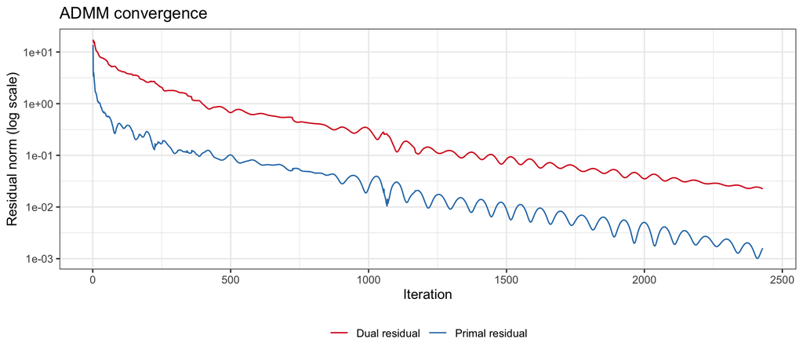

```r
# Convergence trace
conv_df <- solver$history
ggplot(conv_df, aes(x = iter)) +
  geom_line(aes(y = r_primal, colour = "Primal residual")) +
  geom_line(aes(y = r_dual,   colour = "Dual residual")) +
  scale_y_log10() +
  scale_colour_manual(values = c("Primal residual" = "#2c7bb6",
                                 "Dual residual"   = "#d7191c"),
                      name = NULL) +
  labs(title = "ADMM convergence",
       x = "Iteration", y = "Residual norm (log scale)") +
  theme_bw() +
  theme(legend.position = "bottom")
```

# 5 Results

## 5.1 Prepare a long-format data frame

```r
latent_years <- inp$metadata$first_latent_year:inp$metadata$last_latent_year

# Long format: one row per (tract, year)
X_long <- as.data.frame(X_hat)
colnames(X_long) <- as.character(latent_years)
X_long$GEOID     <- rownames(X_hat)

X_long <- tidyr::pivot_longer(
  X_long,
  cols      = -GEOID,
  names_to  = "year",
  values_to = "med_inc_hat"
)
X_long$year <- as.integer(X_long$year)
```

## 5.2 Time series: selected tracts

Pick a handful of tracts to visualise the recovered annual signal alongside the observed 5-year ACS values.

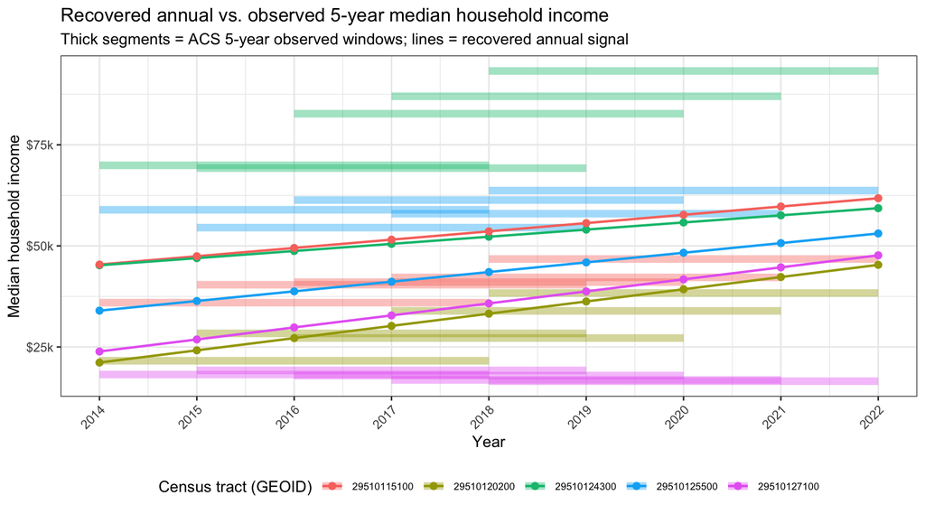

```r
# Observed Y in long format
Y_long <- as.data.frame(inp$Y)
colnames(Y_long) <- as.character(inp$metadata$year_ends)
Y_long$GEOID     <- rownames(inp$Y)

Y_long <- tidyr::pivot_longer(
  Y_long,
  cols      = -GEOID,
  names_to  = "year_end",
  values_to = "med_inc_obs"
)
Y_long$year_end <- as.integer(Y_long$year_end)

# Select a few representative tracts (highest, median, lowest income)
inc_summary <- rowMeans(inp$Y, na.rm = TRUE)
sel_geoids  <- names(sort(inc_summary))[
  round(seq(1, length(inc_summary), length.out = 5))
]

X_sel <- X_long[X_long$GEOID %in% sel_geoids, ]
Y_sel <- Y_long[Y_long$GEOID %in% sel_geoids, ]

ggplot() +
  # Observed 5-year MA: horizontal segments spanning the window
  geom_segment(
    data = Y_sel,
    aes(x = year_end - 4, xend = year_end,
        y = med_inc_obs,  yend = med_inc_obs,
        colour = GEOID),
    linewidth = 2.5, alpha = 0.4
  ) +
  # Recovered annual signal
  geom_line(
    data = X_sel,
    aes(x = year, y = med_inc_hat, colour = GEOID),
    linewidth = 0.8
  ) +
  geom_point(
    data = X_sel,
    aes(x = year, y = med_inc_hat, colour = GEOID),
    size = 2
  ) +
  scale_y_continuous(labels = scales::dollar_format(scale = 1e-3, suffix = "k")) +
  scale_x_continuous(breaks = latent_years) +
  labs(
    title    = "Recovered annual vs. observed 5-year median household income",
    subtitle = "Thick segments = ACS 5-year observed windows; lines = recovered annual signal",
    x = "Year", y = "Median household income",
    colour = "Census tract (GEOID)"
  ) +
  theme_bw() +
  theme(legend.position  = "bottom",
        axis.text.x      = element_text(angle = 45, hjust = 1),
        legend.text      = element_text(size = 7))
```

## 5.3 Spatial maps: recovered income by year

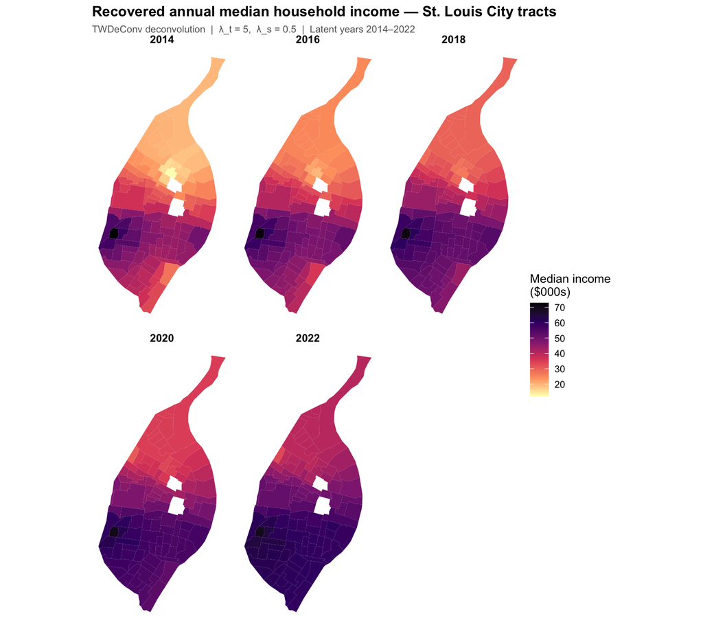

```r
# Join X_hat back to sf geometries from the first ACS fetch
# We need to re-fetch with geometry for the sf object
# (prep_acs_for_deconv stores the sf in the first ACS call internally;
#  here we reconstruct from the GEOID order in inp$Y)
# If you saved the sf object separately, use that instead.

# Get tract geometries via tidycensus
tracts_sf <- tidycensus::get_acs(
  geography = "tract",
  variables = "B19013_001",
  state     = "MO",
  county    = "St. Louis City",
  year      = 2022,
  survey    = "acs5",
  geometry  = TRUE
) |>
  dplyr::select(GEOID, geometry) |>
  dplyr::distinct(GEOID, .keep_all = TRUE)

# Attach recovered estimates for selected years (include 2020)
years_to_map <- c(2014, 2016, 2018, 2020, 2022)

map_df <- X_long |>
  dplyr::filter(year %in% years_to_map) |>
  dplyr::left_join(tracts_sf, by = "GEOID") |>
  sf::st_as_sf()

ggplot(map_df) +
  geom_sf(aes(fill = med_inc_hat / 1000), colour = NA) +
  facet_wrap(~ year, ncol = 3) +
  scale_fill_viridis_c(
    option = "magma", direction = -1,
    name   = "Median income\n($000s)",
    na.value = "grey80"
  ) +
  labs(
    title    = "Recovered annual median household income — St. Louis City tracts",
    subtitle = paste0("TWDeConv deconvolution  |  λ_t = 5,  λ_s = 0.5",
                      "  |  Latent years ", min(latent_years), "–", max(latent_years))
  ) +
  theme_void() +
  theme(
    strip.text       = element_text(face = "bold", size = 10),
    legend.position  = "right",
    plot.title       = element_text(face = "bold"),
    plot.subtitle    = element_text(colour = "grey40", size = 9)
  )
```

## 5.4 Summary statistics across tracts

```r
# Compare observed (Y) vs. recovered (X_hat) distributions
cat("--- Observed ACS 5-year estimates (Y) ---\n")
```

```
## --- Observed ACS 5-year estimates (Y) ---
```

```r
print(summary(as.vector(inp$Y)))
```

```
##    Min. 1st Qu.  Median    Mean 3rd Qu.    Max.    NA's
##   14735   28919   43350   45357   58649   96029       4
```

```r
cat("\n--- Recovered annual estimates (X_hat) ---\n")
```

```
##
## --- Recovered annual estimates (X_hat) ---
```

```r
print(summary(as.vector(X_hat)))
```

```
##    Min. 1st Qu.  Median    Mean 3rd Qu.    Max.
##   12059   35713   45623   44292   53816   72898
```

```r
# Coefficient of variation across years (how much annual variation recovered)
cv_tract <- apply(X_hat, 1, function(x) sd(x, na.rm = TRUE) / mean(x, na.rm = TRUE))
cat("\n--- Within-tract CV of recovered annual signal ---\n")
```

```
##
## --- Within-tract CV of recovered annual signal ---
```

```r
print(summary(cv_tract))
```

```
##    Min. 1st Qu.  Median    Mean 3rd Qu.    Max.
## 0.01903 0.09885 0.13614 0.14959 0.20464 0.37917
```

# 6 Sensitivity to $\lambda$ Parameters

Since we lack ground truth for real data, it is good practice to check how sensitive the results are to the choice of regularization parameters.

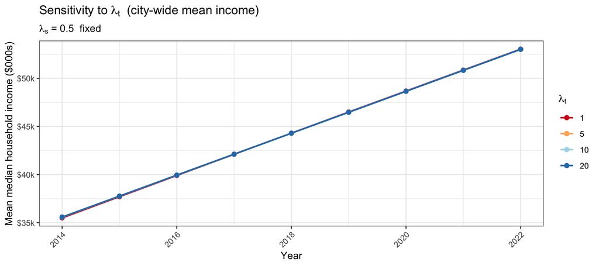

```r
lambdas <- c(1, 5, 10, 20)

results_lt <- lapply(lambdas, function(lt) {
  X_tmp <- solve_deconv(
    Y = Y_k, M = inp$M, W = W_k, D = inp$D, Ls = inp$Ls,
    lambda_t = lt, lambda_s = 0.5
  )
  data.frame(
    lambda_t = lt,
    year     = latent_years,
    mean_inc = colMeans(X_tmp, na.rm = TRUE) * 1000   # back to dollars
  )
})
results_lt <- do.call(rbind, results_lt)
results_lt$lambda_t <- factor(results_lt$lambda_t)

ggplot(results_lt, aes(x = year, y = mean_inc / 1000,
                        colour = lambda_t, group = lambda_t)) +
  geom_line(linewidth = 0.8) +
  geom_point(size = 2) +
  scale_y_continuous(labels = scales::dollar_format(scale = 1, suffix = "k")) +
  scale_colour_brewer(palette = "RdYlBu", name = expression(lambda[t])) +
  labs(
    title = expression("Sensitivity to " * lambda[t] * "  (city-wide mean income)"),
    subtitle = expression(lambda[s] * " = 0.5  fixed"),
    x = "Year", y = "Mean median household income ($000s)"
  ) +
  theme_bw() +
  theme(legend.position = "right",
        axis.text.x = element_text(angle = 45, hjust = 1))
```

# 7 Validation: Comparison with 2020 ACS 1-Year Estimates

## 7.1 Why not the 2020 Decennial Census?

The **2020 Decennial Census does not collect income data** — it only covers basic demographics (population, race, housing units). Income has been measured exclusively by the ACS since the Census long-form was discontinued after 2000.

The closest independent benchmark is the **2020 ACS 1-year experimental estimates**, released by the Census Bureau with caveats about reduced data quality due to COVID-19 field disruptions. Crucially, **ACS 1-year data is only published for areas with population ≥ 65,000**, so tract-level 2020 annual estimates do not exist from any Census source. This is precisely the gap TWDeConv fills.

## 7.2 City-level sanity check

```r
# -- 1. Fetch 2020 ACS 1-year estimate for St. Louis City (county level) ----
# Note: survey="acs1", year=2020 returns the experimental 1-year estimates.
acs1_2020 <- tryCatch(
  tidycensus::get_acs(
    geography = "county",
    variables = c(med_inc = "B19013_001"),
    state     = "MO",
    county    = "510",
    year      = 2020,
    survey    = "acs1"
  ),
  error = function(e) {
    message("2020 ACS 1-year fetch failed: ", conditionMessage(e))
    NULL
  }
)

# -- 2. Deconvolved 2020 city-level estimate (unweighted tract mean) ----------
x_2020_tract <- X_long$med_inc_hat[X_long$year == 2020]
x_2020_city  <- mean(x_2020_tract, na.rm = TRUE)

# -- 3. Print comparison ------------------------------------------------------
cat("=== 2020 Median Household Income — St. Louis City ===\n\n")
```

```
## === 2020 Median Household Income — St. Louis City ===
```

```r
cat(sprintf("TWDeConv deconvolved (tract mean):  $%s\n",
            format(round(x_2020_city), big.mark = ",")))
```

```
## TWDeConv deconvolved (tract mean):  $48,654
```

```r
if (!is.null(acs1_2020)) {
  cat(sprintf("ACS 1-year 2020 (city, experimental): $%s  (MOE: $%s)\n",
              format(acs1_2020$estimate[1], big.mark = ","),
              format(acs1_2020$moe[1],      big.mark = ",")))
  cat(sprintf("Difference: $%s\n",
              format(round(x_2020_city - acs1_2020$estimate[1]), big.mark = ",")))
} else {
  cat("ACS 1-year 2020 not available (try again when Census API is accessible).\n")
}
```

```
## ACS 1-year 2020 not available (try again when Census API is accessible).
```

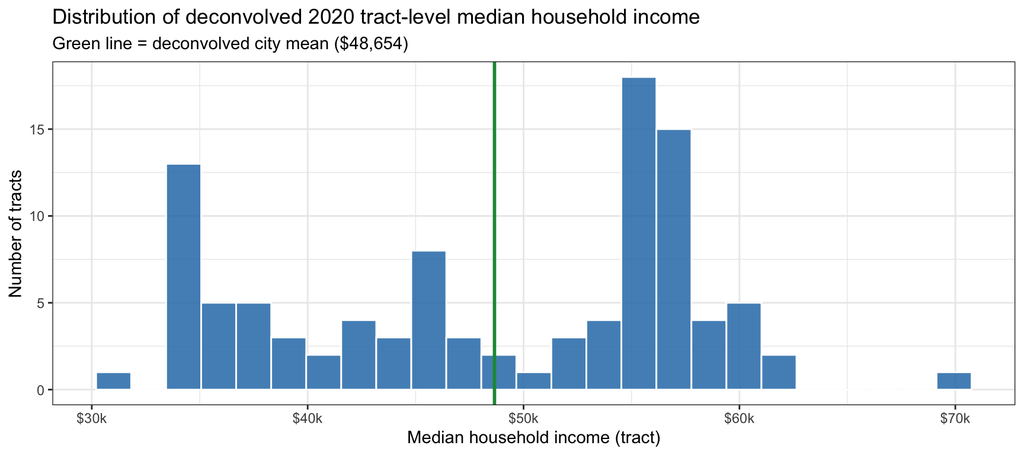

```r
# -- 4. Tract distribution for 2020 ------------------------------------------
x2020_df <- data.frame(med_inc_2020 = x_2020_tract[!is.na(x_2020_tract)])

ggplot(x2020_df, aes(x = med_inc_2020 / 1000)) +
  geom_histogram(bins = 25, fill = "#2c7bb6", colour = "white", alpha = 0.85) +
  { if (!is.null(acs1_2020))
      geom_vline(xintercept = acs1_2020$estimate[1] / 1000,
                 colour = "#d7191c", linewidth = 1, linetype = "dashed")
  } +
  geom_vline(xintercept = x_2020_city / 1000,
             colour = "#1a9641", linewidth = 1, linetype = "solid") +
  scale_x_continuous(labels = scales::dollar_format(suffix = "k")) +
  labs(
    title    = "Distribution of deconvolved 2020 tract-level median household income",
    subtitle = paste0(
      "Green line = deconvolved city mean ($",
      format(round(x_2020_city), big.mark = ","), ")",
      if (!is.null(acs1_2020))
        paste0("   |   Red dashed = ACS 1-yr city estimate ($",
               format(acs1_2020$estimate[1], big.mark = ","), ")")
      else ""
    ),
    x = "Median household income (tract)", y = "Number of tracts"
  ) +
  theme_bw()
```

## 7.3 Tract-level 2020 map

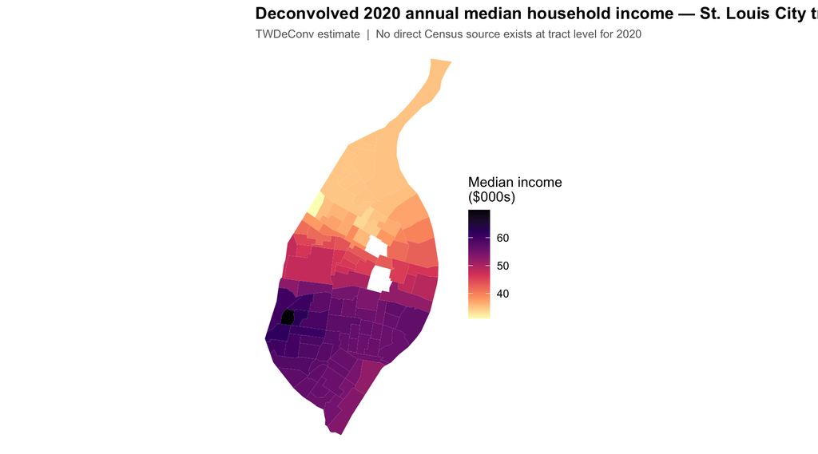

```r
map_2020 <- X_long |>
  dplyr::filter(year == 2020) |>
  dplyr::left_join(tracts_sf, by = "GEOID") |>
  sf::st_as_sf()

ggplot(map_2020) +
  geom_sf(aes(fill = med_inc_hat / 1000), colour = NA) +
  scale_fill_viridis_c(
    option   = "magma", direction = -1,
    name     = "Median income\n($000s)",
    na.value = "grey80"
  ) +
  labs(
    title    = "Deconvolved 2020 annual median household income — St. Louis City tracts",
    subtitle = "TWDeConv estimate  |  No direct Census source exists at tract level for 2020"
  ) +
  theme_void() +
  theme(
    legend.position = "right",
    plot.title      = element_text(face = "bold"),
    plot.subtitle   = element_text(colour = "grey40", size = 9)
  )
```